# Clase 12. Filtro HP

Benjamin Oliva

14/08/2025

## Filtro Hodrick & Prescott (1997)

El articulo original es una discusion respecto de como modelar la brecha del PIB: “Modelling the output gap - Hodrick-Prescott filter”. Estos modelos fueron desarrollados por Hodrick & Prescott (1997), quienes sugieren algunos valores - constantes - para el coeficiente de castigo por desviaciones respecto de la trayectoria de largo plazo ($\lambda$):

- $\lambda$ = 100 for yearly data
- $\lambda$ = 1600 for quarterly data
- $\lambda$ = 14400 for monthly data

# Importamos Datos desde un archivo de R:

Los datos “cargados” son los originales y los ajustados por estacionalidad. Los cuales son:

```r
load("Datos_Ad.RData")

head(Datos_Ad)
```

```
##        FECHA     INPC     TC CETE28    IGAE     IPI  INPC_Ad  TC_Ad CETE28_Ad
## 1 2000-01-01 44.93083 9.4878  16.19 71.9852 90.7125 44.76314 9.4878     16.19
## 2 2000-02-01 45.32938 9.4252  15.81 72.2534 91.4934 45.17539 9.4252     15.81
## 3 2000-03-01 45.58068 9.2876  13.66 74.6511 93.1033 45.39320 9.2876     13.66
## 4 2000-04-01 45.84002 9.3903  12.93 71.3747 91.8422 45.70325 9.3903     12.93
## 5 2000-05-01 46.01138 9.5158  14.18 75.4207 92.1629 46.09141 9.5158     14.18
## 6 2000-06-01 46.28392 9.8295  15.65 74.9497 95.1094 46.43430 9.8295     15.65
##    IGAE_Ad   IPI_Ad
## 1 74.19995 91.61798
## 2 73.85998 91.76105
## 3 73.59885 92.39186
## 4 73.73813 92.93440
## 5 73.98389 92.75686
## 6 73.80197 92.97452
```

## Conversion a series de tiempo:

```r
INPC <- ts(Datos_Ad$INPC_Ad, start = c(2000, 1), freq = 12)

TC <- ts(Datos_Ad$TC_Ad, start = c(2000, 1), freq = 12)
```

## Filtro Hodrick-Prescott:

### INPC:

```r
#?hpfilter

INPC_hpf <- hpfilter(INPC, freq = 14400)

names(INPC_hpf)
```

```
##  [1] "cycle"   "trend"   "fmatrix" "title"   "xname"   "call"    "type"
##  [8] "lambda"  "method"  "x"
```

```r
INPC_hpf$cycle
```

```
##                Jan           Feb           Mar           Apr           May
## 2000 -0.5091713476 -0.3324365730 -0.3501034600 -0.2754469836 -0.1224952140
## 2001  0.3135622099  0.0737139355  0.1160367158  0.1915995910  0.3158372841
## 2002 -0.0382601010 -0.2661927549 -0.2601433176 -0.1298261437  0.0215626024
## 2003  0.0572374218  0.0190452653  0.1132665081  0.0826978960 -0.0030216905
## 2004 -0.1021042075  0.0475283380  0.0017106830 -0.0152265012 -0.0336343447
## 2005  0.0961214716  0.1142290277  0.1482013533  0.2756599334  0.2858013934
## 2006  0.0874516762  0.0006218902 -0.1579673995 -0.1398848222 -0.2376078176
## 2007  0.0098453166 -0.0218715994 -0.1530824914 -0.2687641671 -0.4078870042
## 2008 -0.5372060927 -0.5894283162 -0.4280295567 -0.3698413336 -0.2773011034
## 2009  0.3395118199  0.2313760672  0.3049604603  0.4817324032  0.4767662655
## 2010  0.2765469092  0.4390896690  0.6459620531  0.3955246078  0.1815618738
## 2011  0.0675679470  0.1010201014 -0.0478709605 -0.0380354564 -0.3240374498
## 2012  0.2058648125  0.1082900008 -0.1429162764 -0.3537812408 -0.3240321495
## 2013 -0.1968290237 -0.0653738348  0.2236707033  0.3329681775  0.3527781794
```

[output cut: 60 more lines]

```r
INPC_hpf$trend
```

```
##            Jan       Feb       Mar       Apr       May       Jun       Jul
## 2000  45.27231  45.50782  45.74331  45.97869  46.21390  46.44884  46.68338
## 2001  48.07637  48.30522  48.53292  48.75944  48.98472  49.20876  49.43153
## 2002  50.74316  50.95793  51.17169  51.38446  51.59622  51.80695  52.01664
## 2003  53.25320  53.45594  53.65782  53.85890  54.05923  54.25889  54.45793
## 2004  55.64172  55.83746  56.03272  56.22750  56.42176  56.61549  56.80868
## 2005  57.95528  58.14449  58.33335  58.52195  58.71041  58.89885  59.08743
## 2006  60.23137  60.42576  60.62167  60.81929  61.01878  61.22029  61.42397
## 2007  62.69726  62.91888  63.14344  63.37102  63.60171  63.83556  64.07260
## 2008  65.56024  65.81824  66.07871  66.34140  66.60604  66.87234  67.13998
## 2009  68.75610  69.02443  69.29182  69.55810  69.82309  70.08667  70.34874
## 2010  71.88730  72.13807  72.38726  72.63490  72.88109  73.12597  73.36965
## 2011  74.81428  75.05336  75.29233  75.53134  75.77052  76.01003  76.24998
## 2012  77.70227  77.94634  78.19087  78.43586  78.68125  78.92700  79.17300
## 2013  80.65009  80.89582  81.14122  81.38623  81.63076  81.87478  82.11825
```

[output cut: 35 more lines]

```r
INPC_hpf$lambda
```

```
## [1] 14400
```

```r
INPC_hpf$x
```

```
##            Jan       Feb       Mar       Apr       May       Jun       Jul
## 2000  44.76314  45.17539  45.39320  45.70325  46.09141  46.43430  46.70259
## 2001  48.38993  48.37893  48.64896  48.95104  49.30056  49.49358  49.45449
## 2002  50.70490  50.69173  50.91155  51.25463  51.61778  51.95173  52.18417
## 2003  53.31044  53.47498  53.77109  53.94160  54.05621  54.19265  54.34518
## 2004  55.53962  55.88499  56.03443  56.21227  56.38812  56.57961  56.79063
## 2005  58.05140  58.25872  58.48155  58.79761  58.99621  59.04801  59.32994
## 2006  60.31882  60.42638  60.46371  60.67941  60.78117  60.94524  61.15287
## 2007  62.70710  62.89701  62.99036  63.10226  63.19382  63.38302  63.68394
## 2008  65.02303  65.22881  65.65068  65.97156  66.32874  66.71955  67.11718
## 2009  69.09561  69.25580  69.59678  70.03983  70.29986  70.55131  70.76531
## 2010  72.16385  72.57716  73.03322  73.03042  73.06266  73.16429  73.33891
## 2011  74.88185  75.15438  75.24446  75.49330  75.44648  75.56494  75.93567
## 2012  77.90814  78.05463  78.04796  78.08208  78.35722  78.83579  79.28409
## 2013  80.45326  80.83044  81.36489  81.71920  81.98354  82.05167  82.03321
```

[output cut: 35 more lines]

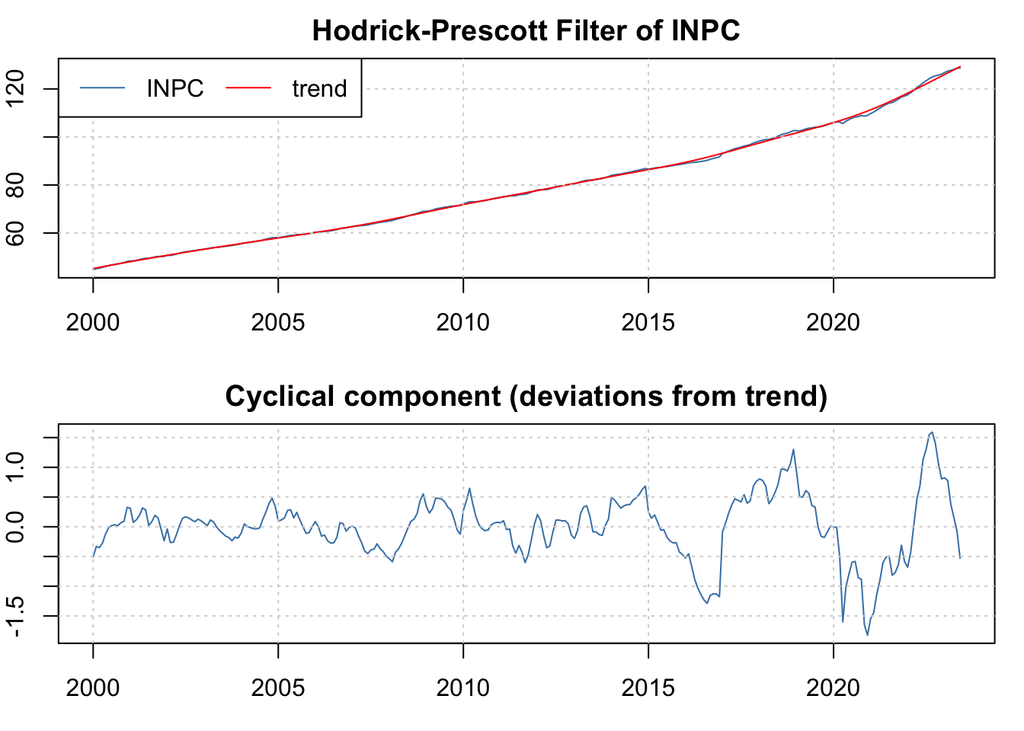

```r
plot(INPC_hpf)
```

```r
INPC_Cycle <- INPC_hpf$cycle

INPC_Trend <- INPC_hpf$trend
```

### TC:

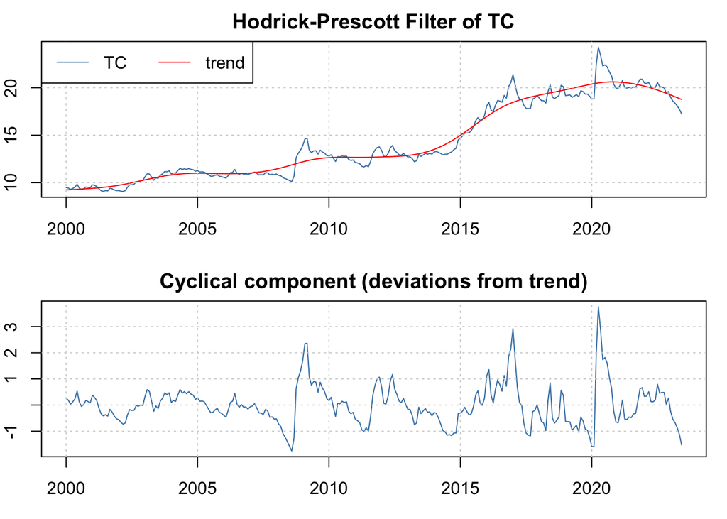

```r
TC_hpf <- hpfilter(TC, freq = 14400)

plot(TC_hpf)
```

```r
TC_Cycle <- TC_hpf$cycle

TC_Trend <- TC_hpf$trend
```

# DataFrame:

```r
Datos_HPF <- cbind(Datos_Ad$FECHA,
                  data.frame(cbind(INPC,
                                   INPC_Trend,
                                   INPC_Cycle,
                                   TC,
                                   TC_Trend,
                                   TC_Cycle)))
```

# Hodrick-Prescott planteado por St-Amant & van Norden

Método modificado de HP consiste en minimizar los valores de la serie $\{ \tau_t \}_{t=1}^T$:
$$\sum_{t=1}^T (y_t - \tau_t)^2 + \lambda
\sum_{t=2}^{T-1} [(\tau_{t+1} - \tau_t) - (\tau_t - \tau_{t-1})]^2 +
\lambda_{ss} \sum_{t=T-j}^{T} [\Delta \tau_t - u_{ss}]$$

Donde $\lambda$ es una parámetro fijo (determinado ex-ante), $\tau_t$ es un componente de tendencia de $y_t$, y los nuevos parámetros son $u_{ss}$ y $\lambda_{ss}$ ajustadas por el procedimiento de Marcet y Ravn (2004).

Este procedimiento asume que parte del filtro HP y que esta versión tiene el problema de pérdida de información al final y al principio de la muestra. La razón es que es un procedimeinto univariado que requiere de mucha información futura y pasada para mejorar el ajuste.

El compoenente adicional al filtro HP es un componente de castigo por desviaciones de la tasa de crecimiento de largo plazo, $u_{ss}$.

El proceso de selección de $\lambda_{ss}$ es e propuesto por Marcet y Ravn (2004), el cual consiste en utilizar un $\lambda$ convencional y el filtro HP convencional para estimar la siguiente función:
$$F(\lambda) = \frac{\sum_{t=2}^{T-1} ((\tau_{t+1}
- \tau_t) - (\tau_t - \tau_{t-1}))^2}{\sum_{t=1}^T (y_t -
\tau_t)^2}$$

Entonces el valor de $\lambda_{ss}$ será aquel que:
$$F(\lambda_{ss}) = \frac{\sum_{t=2}^{T-1}
((\tau_{t+1} - \tau_t) - (\tau_t - \tau_{t-1}))^2}{\sum_{t=1}^T (y_t -
\tau_t)^2} = F(\lambda)$$

nota: Antón (2009) estimó $\lambda_{ss} = 1096$ para datos trimestrales del PIB.

```r
st_amant_van_norden_filter <- function(ts_data) {

  # Calculate the variance of the series
  variance <- var(ts_data)

  # Calculate the first difference of the series
  diff_ts <- diff(ts_data)

  # Calculate the variance of the first difference of the series
  variance_diff <- var(diff_ts)

  # Calculate lambda based on the St-Amant and Van Norden formula
  lambda <- variance / variance_diff

  # Apply the Hodrick-Prescott filter with the computed lambda
  HP_Filter_StAmantVanNorden <- hpfilter(ts_data, freq = lambda)

  return(HP_Filter_StAmantVanNorden)
}
```

### Aplicando a una serie:

```r
IGAE <- ts(Datos_Ad$IGAE, start = c(2000, 1), freq = 12)

st_amant_van_norden_filter(IGAE)
```

```
##
## Title:
##  Hodrick-Prescott Filter
##
## Call:
##  hpfilter(x = ts_data, freq = lambda)
##
## Method:
##  hpfilter
##
## Filter Type:
##  lambda
##
## Series:
##  ts_data
##
##          ts_data  Trend      Cycle
## Jan 2000   71.99  72.15  -0.160003
## Feb 2000   72.25  72.69  -0.435741
## Mar 2000   74.65  73.22   1.432963
## Apr 2000   71.37  73.68  -2.301856
## May 2000   75.42  74.14   1.278116
## Jun 2000   74.95  74.48   0.470258
## Jul 2000   74.03  74.67  -0.637013
## Aug 2000   74.84  74.74   0.102707
## Sep 2000   75.72  74.66   1.059610
## Oct 2000   74.41  74.40   0.016494
## Nov 2000   74.32  74.04   0.279306
## Dec 2000   73.08  73.65  -0.573948
## Jan 2001   73.60  73.35   0.255454
## Feb 2001   71.05  73.17  -2.121266
## Mar 2001   74.40  73.20   1.204858
## Apr 2001   71.92  73.30  -1.380111
## May 2001   74.86  73.47   1.382574
## Jun 2001   73.79  73.57   0.220943
## Jul 2001   72.89  73.57  -0.685088
## Aug 2001   74.04  73.50   0.536664
## Sep 2001   73.82  73.30   0.520361
## Oct 2001   73.41  72.95   0.461546
## Nov 2001   73.05  72.51   0.537269
```

[output cut: 244 more lines]

```
## Apr 2022   98.26  99.16  -0.903254
## May 2022  101.72  99.76   1.963302
## Jun 2022  100.42 100.18   0.239770
## Jul 2022   99.60 100.49  -0.881850
## Aug 2022  101.51 100.76   0.755653
## Sep 2022   99.15 101.00  -1.849357
## Oct 2022  100.42 101.26  -0.844186
## Nov 2022  105.15 101.46   3.686168
## Dec 2022  103.48 101.41   2.072341
## Jan 2023   99.32 101.26  -1.938169
## Feb 2023   97.20 101.37  -4.168194
## Mar 2023  104.10 101.92   2.172332
## Apr 2023  100.49 102.70  -2.205168
## May 2023  106.11 103.68   2.436160
## Jun 2023  104.55 104.65  -0.098696
```

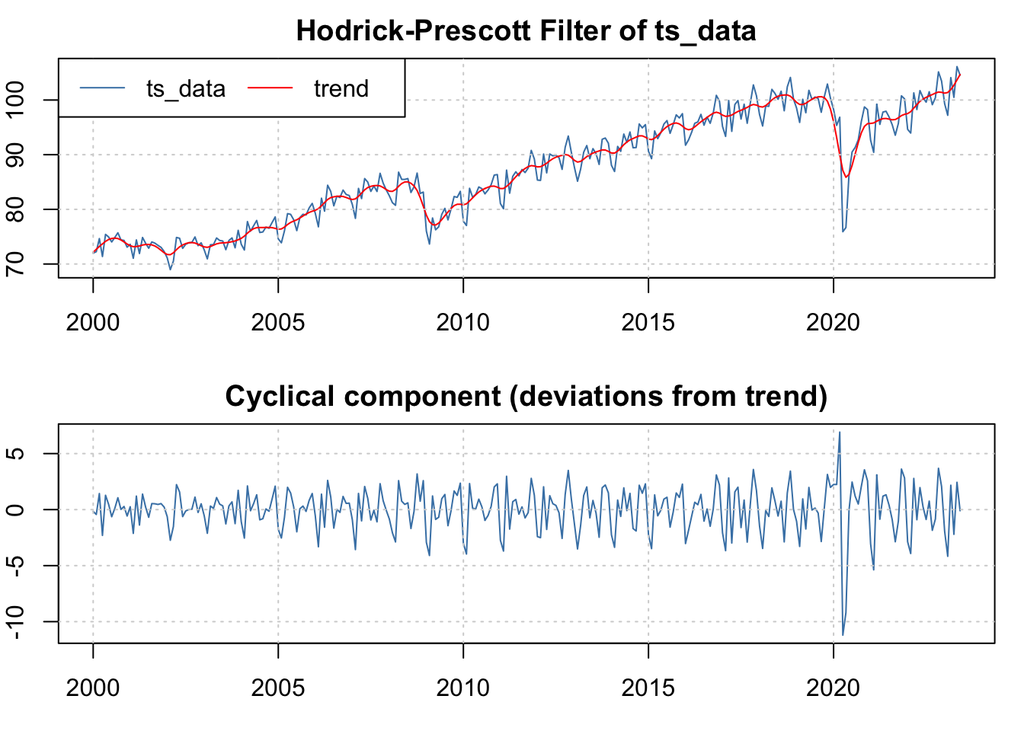

```r
IGAE_hpf_SAvN <- st_amant_van_norden_filter(IGAE)

plot(IGAE_hpf_SAvN)
```

```r
IGAE_Cycle <- IGAE_hpf_SAvN$cycle

IGAE_Trend <- IGAE_hpf_SAvN$trend
```